# capstone-proj2

project Description: I build a model to accurately predict whether the patients have diabetes or not? Following approaches are made to build a model:

1. Performed descriptive analysis on glucose, blood pressure, skin thickness, insulin and bmi. 2.Generated visualization reports on those variables like histograms to treat the missing values. 3..Check the balance of the data by plotting the count of outcomes by their value and To overcome with this Imbalancing of dataset we have few techniques like undersampling technique, over sampling technique and ensemble method. 4.Created scatter charts between the pair of variables to understand the relationships. 5.Performed correlation analysis and this can be explored it using a heat map. 6.Applied an appropriate classification algorithm to build a model and Compared various models with the results from KNN. 7.Created a classification report to analyses sensitivity, specificity, AUC(ROC curve) .

```python
import numpy as np
import pandas as pd
import matplotlib.pyplot as plt
%matplotlib inline
import seaborn as sns
import warnings
warnings.filterwarnings("ignore")
```

## IMPORT DATASET

```python
healthcare=pd.read_csv("health care diabetes.csv")
healthcare.head()
```

|  | Pregnancies | Glucose | BloodPressure | SkinThickness | Insulin | BMI | DiabetesPedigreeFunction | Age | Outcome |
| --- | --- | --- | --- | --- | --- | --- | --- | --- | --- |
| 0 | 6 | 148 | 72 | 35 | 0 | 33.6 | 0.627 | 50 | 1 |
| 1 | 1 | 85 | 66 | 29 | 0 | 26.6 | 0.351 | 31 | 0 |
| 2 | 8 | 183 | 64 | 0 | 0 | 23.3 | 0.672 | 32 | 1 |
| 3 | 1 | 89 | 66 | 23 | 94 | 28.1 | 0.167 | 21 | 0 |
| 4 | 0 | 137 | 40 | 35 | 168 | 43.1 | 2.288 | 33 | 1 |

```python
healthcare.isnull().any()
```

```
Pregnancies                 False
Glucose                     False
BloodPressure               False
SkinThickness               False
Insulin                     False
BMI                         False
DiabetesPedigreeFunction    False
Age                         False
Outcome                     False
dtype: bool
```

```python
healthcare.shape
```

```
(768, 9)
```

```python
healthcare.columns
```

```
Index(['Pregnancies', 'Glucose', 'BloodPressure', 'SkinThickness', 'Insulin',
       'BMI', 'DiabetesPedigreeFunction', 'Age', 'Outcome'],
      dtype='object')
```

```python
convert_zero_values=['Glucose', 'BloodPressure', 'SkinThickness', 'Insulin',
       'BMI']
for column in convert_zero_values:
    healthcare[column]=healthcare[column].replace(0,np.NaN)
    mean=int(healthcare[column].mean(skipna=True))
    healthcare[column]=healthcare[column].replace(np.NaN,mean)
```

## 1. Perform descriptive analysis

```python
healthcare[['Glucose', 'BloodPressure', 'SkinThickness', 'Insulin',
       'BMI']].describe().T
```

|  | count | mean | std | min | 25% | 50% | 75% | max |
| --- | --- | --- | --- | --- | --- | --- | --- | --- |
| Glucose | 768.0 | 121.682292 | 30.435999 | 44.0 | 99.75 | 117.0 | 140.25 | 199.0 |
| BloodPressure | 768.0 | 72.386719 | 12.096642 | 24.0 | 64.00 | 72.0 | 80.00 | 122.0 |
| SkinThickness | 768.0 | 29.108073 | 8.791221 | 7.0 | 25.00 | 29.0 | 32.00 | 99.0 |
| Insulin | 768.0 | 155.281250 | 85.021550 | 14.0 | 121.50 | 155.0 | 155.00 | 846.0 |
| BMI | 768.0 | 32.450911 | 6.875366 | 18.2 | 27.50 | 32.0 | 36.60 | 67.1 |

## 2. Histograms

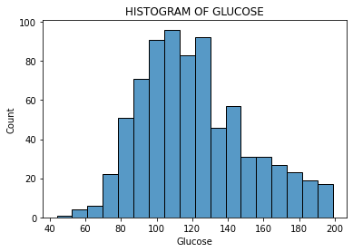

```python
plt.title('HISTOGRAM OF GLUCOSE')
sns.histplot(healthcare.Glucose)
```

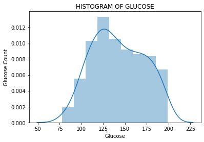

```python
plt.title('HISTOGRAM OF GLUCOSE')

sns.distplot(healthcare['Glucose'][healthcare['Outcome']==1])
plt.xticks()
plt.ylabel('Glucose Count')
```

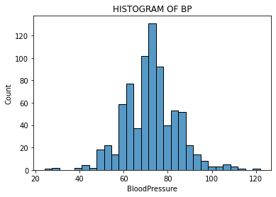

```python
plt.title('HISTOGRAM OF BP')
sns.histplot(healthcare.BloodPressure)
```

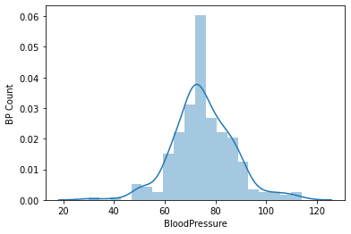

```python
sns.distplot(healthcare['BloodPressure'][healthcare['Outcome']==1])
plt.xticks()
plt.ylabel('BP Count')
```

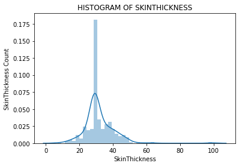

```python
plt.title('HISTOGRAM OF SKINTHICKNESS')

sns.distplot(healthcare['SkinThickness'][healthcare['Outcome']==1])
plt.xticks()
plt.ylabel('SkinThickness Count')
```

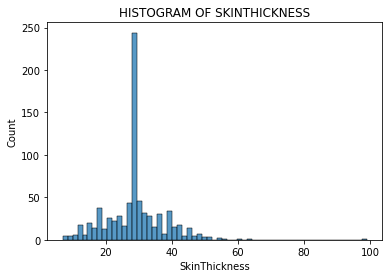

```python
plt.title('HISTOGRAM OF SKINTHICKNESS')
sns.histplot(healthcare.SkinThickness)
```

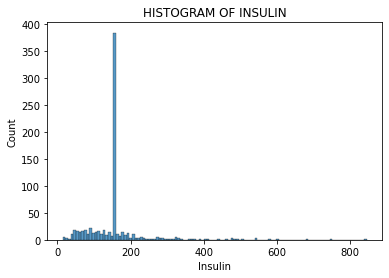

```python
sns.histplot(healthcare.Insulin)
plt.title('HISTOGRAM OF INSULIN')
```

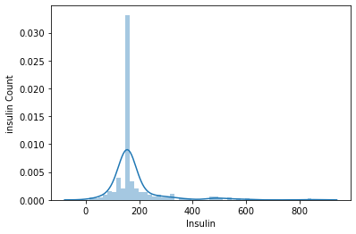

```python
sns.distplot(healthcare['Insulin'][healthcare['Outcome']==1])
plt.xticks()
plt.ylabel('insulin Count')
```

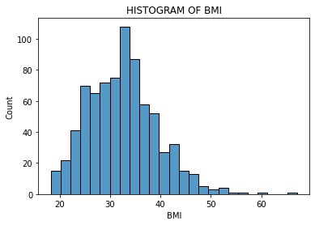

```python
sns.histplot(healthcare.BMI)
plt.title('HISTOGRAM OF BMI')
```

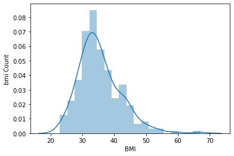

```python
sns.distplot(healthcare['BMI'][healthcare['Outcome']==1])
plt.xticks()
plt.ylabel('bmi Count')
```

# #3.Create a count (frequency) plot

```python
healthcare.dtypes
```

```
Pregnancies                   int64
Glucose                     float64
BloodPressure               float64
SkinThickness               float64
Insulin                     float64
BMI                         float64
DiabetesPedigreeFunction    float64
Age                           int64
Outcome                       int64
dtype: object
```

```python
healthcare.dtypes.value_counts()
```

```
float64    6
int64      3
dtype: int64
```

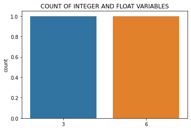

```python
plt.title('COUNT OF INTEGER AND FLOAT VARIABLES')
sns.countplot(healthcare.dtypes.value_counts())
```

# #Data Exploration:

## 1.Check the balance of the data by plotting the count of outcomes by their value

```python
healthcare.columns
```

```
Index(['Pregnancies', 'Glucose', 'BloodPressure', 'SkinThickness', 'Insulin',
       'BMI', 'DiabetesPedigreeFunction', 'Age', 'Outcome'],
      dtype='object')
```

```python
x=healthcare.drop(['Outcome'],axis=1)
y=healthcare['Outcome']
```

```python
y.value_counts()
```

```
0    500
1    268
Name: Outcome, dtype: int64
```